# DSE 200X_ Final Project Analysis_MHolborn_June2023

## Final Project

As the final project for this course, I will be analysing customer product review data from the Amazon Kindle Store to answer the following research question: **Can sentiment analysis be used to predict which Amazon Kindle products received high or low ratings?**

The data used in this project was retrieved from Kaggle: https://www.kaggle.com/datasets/bharadwaj6/kindle-reviews/versions/3?resource=download.

### Import libraries

```python
import pandas as pd
import matplotlib.pyplot as plt
import seaborn as sns
import numpy as np
import nltk
import string
from wordcloud import WordCloud
from collections import Counter, OrderedDict
from nltk.classify import NaiveBayesClassifier
import random
from sklearn.metrics import classification_report, confusion_matrix, ConfusionMatrixDisplay
```

### Import data

```python
amazon_reviews = pd.read_json("../Data/kindle_reviews.json", lines=True)
```

### Conduct an initial exploration of the data

What is the shape of the data?

```python
amazon_reviews.shape
```

```
(982619, 9)
```

The dataset has 9 columns and 982619 rows. What information is contained in the columns?

```python
amazon_reviews.info()
```

```
<class 'pandas.core.frame.DataFrame'>
RangeIndex: 982619 entries, 0 to 982618
Data columns (total 9 columns):
 #   Column          Non-Null Count   Dtype
---  ------          --------------   -----
 0   reviewerID      982619 non-null  object
 1   asin            982619 non-null  object
 2   reviewerName    978820 non-null  object
 3   helpful         982619 non-null  object
 4   reviewText      982619 non-null  object
 5   overall         982619 non-null  int64
 6   summary         982619 non-null  object
 7   unixReviewTime  982619 non-null  int64
 8   reviewTime      982619 non-null  object
dtypes: int64(2), object(7)
memory usage: 67.5+ MB
```

How many missing values are present?

```python
amazon_reviews.isna().sum()
```

```
reviewerID           0
asin                 0
reviewerName      3799
helpful              0
reviewText           0
overall              0
summary              0
unixReviewTime       0
reviewTime           0
dtype: int64
```

How many unique products are present?

```python
len(amazon_reviews.asin.unique())
```

```
61934
```

How many unique reviewers were there?

```python
len(amazon_reviews.reviewerID.unique())
```

```
68223
```

### Select dataset features

Select the reviewText, summary and overall dataset columns for further analysis.

```python
amazon_reviews_subset = amazon_reviews[["reviewText", "summary", "overall"]].copy()
len(amazon_reviews_subset)
```

```
982619
```

Remove duplicate reviews

```python
amazon_reviews_subset = amazon_reviews_subset.drop_duplicates()
len(amazon_reviews_subset)
```

```
982483
```

### Divide reviews into groups corresponding to rating.

Reviews with a rating of less than 3, equal to 3, and greater than 3 will be negative, neutral and positive, respectively.

```python
conditions = [
    amazon_reviews_subset["overall"] < 3,
    amazon_reviews_subset["overall"] == 3,
    amazon_reviews_subset["overall"] > 3
]

choices = ["negative", "neutral", "positive"]

amazon_reviews_subset["sentiment"] = np.select(conditions, choices)

amazon_reviews_subset.head(5)
```

|  | reviewText | summary | overall | sentiment |
| --- | --- | --- | --- | --- |
| 0 | I enjoy vintage books and movies so I enjoyed ... | Nice vintage story | 5 | positive |
| 1 | This book is a reissue of an old one; the auth... | Different... | 4 | positive |
| 2 | This was a fairly interesting read. It had ol... | Oldie | 4 | positive |
| 3 | I'd never read any of the Amy Brewster mysteri... | I really liked it. | 5 | positive |
| 4 | If you like period pieces - clothing, lingo, y... | Period Mystery | 4 | positive |

Count the number of positive and negative reviews

```python
len(amazon_reviews_subset[amazon_reviews_subset["sentiment"] == "positive"])
```

```
829147
```

```python
len(amazon_reviews_subset[amazon_reviews_subset["sentiment"] == "negative"])
```

```
57148
```

Take a sample of 40000 reviews (20000 positive, 20000 negative) for testing

```python
pos_sample = amazon_reviews_subset[amazon_reviews_subset["sentiment"] == "positive"].sample(n=20000,replace=True)
neg_sample = amazon_reviews_subset[amazon_reviews_subset["sentiment"] == "negative"].sample(n=20000,replace=True)

amazon_reviews_sample = pd.concat([pos_sample, neg_sample])
amazon_reviews_sample.head(5)
```

|  | reviewText | summary | overall | sentiment |
| --- | --- | --- | --- | --- |
| 848734 | I loved this new series by Christina Tetreault... | OMG another awesome book | 5 | positive |
| 823954 | Yes! This was a hot read, so hot that I HAD to... | Freaky | 5 | positive |
| 831623 | I was gifted this book in exchange for an hone... | Amazing | 5 | positive |
| 503383 | This short story was very hot. The tension and... | Very hot | 5 | positive |
| 372736 | It was almost painful as the reader to see how... | So Much Pain | 5 | positive |

### Convert reviews to lowercase

```python
amazon_reviews_sample["reviewText"] = amazon_reviews_sample["reviewText"].astype(str).str.lower()
amazon_reviews_sample.head(5)
```

|  | reviewText | summary | overall | sentiment |
| --- | --- | --- | --- | --- |
| 848734 | i loved this new series by christina tetreault... | OMG another awesome book | 5 | positive |
| 823954 | yes! this was a hot read, so hot that i had to... | Freaky | 5 | positive |
| 831623 | i was gifted this book in exchange for an hone... | Amazing | 5 | positive |
| 503383 | this short story was very hot. the tension and... | Very hot | 5 | positive |
| 372736 | it was almost painful as the reader to see how... | So Much Pain | 5 | positive |

### Tokenize text

Split the text into individual words

```python
amazon_reviews_sample["tokenized_review"] =  amazon_reviews_sample.reviewText.apply(nltk.word_tokenize)
amazon_reviews_sample.head(5)
```

|  | reviewText | summary | overall | sentiment | tokenized_review |
| --- | --- | --- | --- | --- | --- |
| 848734 | i loved this new series by christina tetreault... | OMG another awesome book | 5 | positive | [i, loved, this, new, series, by, christina, t... |
| 823954 | yes! this was a hot read, so hot that i had to... | Freaky | 5 | positive | [yes, !, this, was, a, hot, read, ,, so, hot, ... |
| 831623 | i was gifted this book in exchange for an hone... | Amazing | 5 | positive | [i, was, gifted, this, book, in, exchange, for... |
| 503383 | this short story was very hot. the tension and... | Very hot | 5 | positive | [this, short, story, was, very, hot, ., the, t... |
| 372736 | it was almost painful as the reader to see how... | So Much Pain | 5 | positive | [it, was, almost, painful, as, the, reader, to... |

### Remove stop words and punctuation

Remove punctuation and words that are not relevant

```python
# Retrieve punctuation and common english stop words to be removed
removed_words = nltk.corpus.stopwords.words("english") + list(string.punctuation)

# Drop negations from the removed_words list. Negations will be handled later in the analysis.
for word in ['not', 'n\'t', 'no', 'never']:
    if word in removed_words:
        removed_words.remove (word)

# Add some stop words

removed_words.extend(["\'s", "''", "``", "..."])
```

```python
amazon_reviews_sample["without_stop_words"] = amazon_reviews_sample["tokenized_review"].apply(lambda x: [word for word in x if word not in removed_words])
amazon_reviews_sample.head(5)
```

|  | reviewText | summary | overall | sentiment | tokenized_review | without_stop_words |
| --- | --- | --- | --- | --- | --- | --- |
| 848734 | i loved this new series by christina tetreault... | OMG another awesome book | 5 | positive | [i, loved, this, new, series, by, christina, t... | [loved, new, series, christina, tetreault, lov... |
| 823954 | yes! this was a hot read, so hot that i had to... | Freaky | 5 | positive | [yes, !, this, was, a, hot, read, ,, so, hot, ... | [yes, hot, read, hot, get, part, 2, immediatel... |
| 831623 | i was gifted this book in exchange for an hone... | Amazing | 5 | positive | [i, was, gifted, this, book, in, exchange, for... | [gifted, book, exchange, honest, review.this, ... |
| 503383 | this short story was very hot. the tension and... | Very hot | 5 | positive | [this, short, story, was, very, hot, ., the, t... | [short, story, hot, tension, desire, nearly, p... |
| 372736 | it was almost painful as the reader to see how... | So Much Pain | 5 | positive | [it, was, almost, painful, as, the, reader, to... | [almost, painful, reader, see, much, pain, two... |

### Handle negation

Words preceded by negations should not be interpreted as positive

```python
def handle_negation(tokenized_list):

    negation_handled_list = []

    for word in tokenized_list:
        # next_word = tokenized_list[tokenized_list.index(word) + 1]
        if word in ['not', 'n\'t', 'no', 'never']:
            if tokenized_list.index(word) < len (tokenized_list) - 1:
                next_word = tokenized_list[tokenized_list.index(word) + 1]
                negation_handled_list.append("not_" + next_word)
        else:
            negation_handled_list.append(word)

    # negation_handled_list = ', '.join(negation_handled_list)
    return negation_handled_list
```

```python
amazon_reviews_sample["handled_negation"] =  amazon_reviews_sample.without_stop_words.apply(handle_negation)
amazon_reviews_sample.head(5)
```

|  | reviewText | summary | overall | sentiment | tokenized_review | without_stop_words | handled_negation |
| --- | --- | --- | --- | --- | --- | --- | --- |
| 848734 | i loved this new series by christina tetreault... | OMG another awesome book | 5 | positive | [i, loved, this, new, series, by, christina, t... | [loved, new, series, christina, tetreault, lov... | [loved, new, series, christina, tetreault, lov... |
| 823954 | yes! this was a hot read, so hot that i had to... | Freaky | 5 | positive | [yes, !, this, was, a, hot, read, ,, so, hot, ... | [yes, hot, read, hot, get, part, 2, immediatel... | [yes, hot, read, hot, get, part, 2, immediatel... |
| 831623 | i was gifted this book in exchange for an hone... | Amazing | 5 | positive | [i, was, gifted, this, book, in, exchange, for... | [gifted, book, exchange, honest, review.this, ... | [gifted, book, exchange, honest, review.this, ... |
| 503383 | this short story was very hot. the tension and... | Very hot | 5 | positive | [this, short, story, was, very, hot, ., the, t... | [short, story, hot, tension, desire, nearly, p... | [short, story, hot, tension, desire, nearly, p... |
| 372736 | it was almost painful as the reader to see how... | So Much Pain | 5 | positive | [it, was, almost, painful, as, the, reader, to... | [almost, painful, reader, see, much, pain, two... | [almost, painful, reader, see, much, pain, two... |

### Visualize the most common negative and positive sentiments

Extract and group all positive and negative words. Construct a WordCloud for the positive and negative groups.

```python
positive_reviews =  amazon_reviews_sample[amazon_reviews_sample["sentiment"] == "positive"]["handled_negation"]
negative_reviews = amazon_reviews_sample[amazon_reviews_sample["sentiment"] == "negative"]["handled_negation"]
```

```python
positive_words = WordCloud(background_color='white', width=800, height=400).generate(' '.join(positive_reviews.sum()))
```

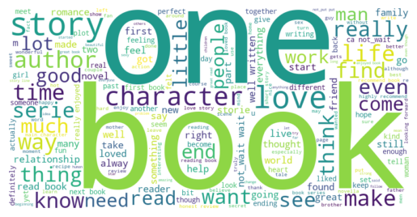

```python
plt.imshow(positive_words, interpolation="bilinear")
plt.axis("off")

# Save the figure
plt.savefig("../Results/Figures/Positive_wordcloud.png", dpi=1200)

plt.show()
```

```python
negative_words = WordCloud(background_color='white', width=800, height=400).generate(' '.join(negative_reviews.sum()))
```

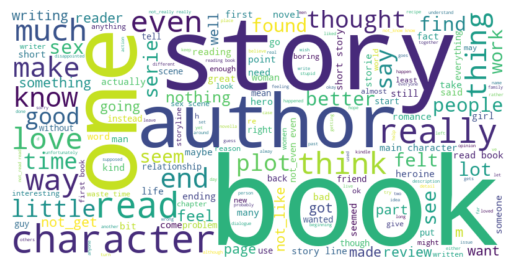

```python
plt.imshow(negative_words, interpolation="bilinear")
plt.axis("off")

# Save the figure
plt.savefig("../Results/Figures/Negative_wordcloud.png", dpi=1200)

plt.show()
```

### Get the counts and frequencies of the positive and negative sentiments

Create lists with all positive and negative words

How many positive words were used?

```python
positive_words = []
for list in positive_reviews:
    positive_words.extend(list)

len (positive_words)
```

```
1128424
```

Many words were used in the positive reviews. How many of these words are unique?

```python
len (set(positive_words))
```

```
62137
```

How many negative words were used?

```python
negative_words = []
for list in negative_reviews:
    negative_words.extend(list)

len (negative_words)
```

```
1058692
```

Less words were used in the negative reviews in comparison to the positive reviews. How many of these words are unique?

```python
len (set(negative_words))
```

```
52560
```

Count the frequencies of the positive and negative words

```python
pos_word_counter = Counter(positive_words)
```

```python
neg_word_counter = Counter(negative_words)
```

### Plot the frequencies

Sort the numerical data

```python
pos_sorted_word_counts = sorted(pos_word_counter.values(), reverse=True)
neg_sorted_word_counts = sorted(neg_word_counter.values(), reverse=True)
```

Plot the positive word count frequencies

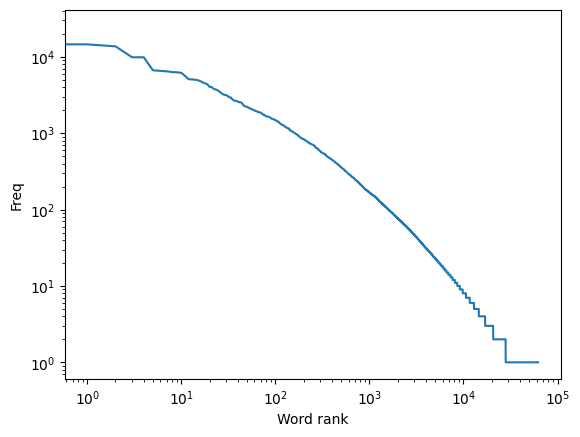

```python
plt.loglog(pos_sorted_word_counts)
plt.ylabel("Freq")
plt.xlabel("Word rank")

# Save the figure
plt.savefig("../Results/Figures/Positive_frequency.png", dpi=1200)

plt.show()
```

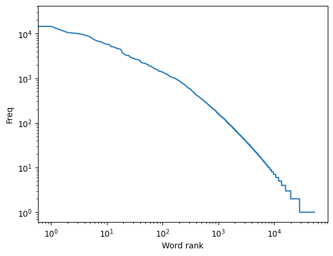

```python
plt.loglog(neg_sorted_word_counts)
plt.ylabel("Freq")
plt.xlabel("Word rank")

# Save the figure
plt.savefig("../Results/Figures/Negative_frequency.png", dpi=1200)

plt.show()
```

### Train a classifier for sentiment analysis

Create a bag of words to house the positive and negative words contained in each review.

```python
# Create a function to build a bag of words for each review

def build_bag_of_words(review):
    return {word:1 for word in review}
```

```python
# Build a list of positive/negative words contained in each review. Associate the term 'pos' or 'neg' with the positive and negative words, respectively.

negative_features = [
    (build_bag_of_words(value), "neg") for value in negative_reviews.values
]

positive_features = [
    (build_bag_of_words(value), "pos") for value in positive_reviews.values
]
```

Classify the data using a Naive Bayes supervised machine learning classifier. Train the data on 80% of the data. Use the remaining 20% for testing purposes.

Determine how many records make up 80% of the data.

```python
pos_split = len (positive_features) * 0.8
round(pos_split)
```

```
16000
```

```python
neg_split = len (negative_features) * 0.8
round(neg_split)
```

```
16000
```

Train the classifier. Check the accuracy of the training set. We expect a high percentage as the classifier algorithm already saw this data. Check the accuracy using the test data. The classifier algorithm has not seen this data.

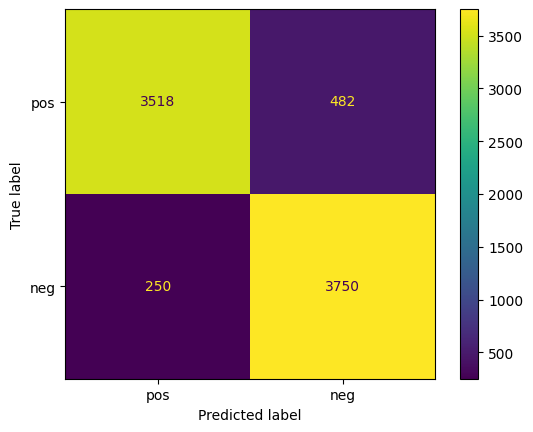

```
Most Informative Features
          not_disappoint = 1                 pos : neg    =    104.3 : 1.0
                     4.5 = 1                 pos : neg    =     73.0 : 1.0
                 deleted = 1                 neg : pos    =     62.1 : 1.0
           not_impressed = 1                 neg : pos    =     52.3 : 1.0
              not_finish = 1                 neg : pos    =     44.7 : 1.0
                  refund = 1                 neg : pos    =     44.6 : 1.0
                  weaves = 1                 pos : neg    =     43.0 : 1.0
                    lame = 1                 neg : pos    =     42.2 : 1.0
                deleting = 1                 neg : pos    =     41.7 : 1.0
           uninteresting = 1                 neg : pos    =     38.3 : 1.0
```

```python
accur_report = pd.DataFrame()

# Create a random sample of positive and negative training data

pos_train = positive_features[:16000]
neg_train = negative_features[:16000]

# Get the remaining test data

pos_test = positive_features[16000:]
neg_test = negative_features[16000:]

# Train the classifier

classifier = NaiveBayesClassifier.train(pos_train + neg_train)

# Test the accuracy

train_accuracy = nltk.classify.util.accuracy(classifier, pos_train + neg_train)*100
test_accuracy = nltk.classify.util.accuracy(classifier, pos_test + neg_test)*100

# Create a classification report

observed_result = []
actual_result = []
pos_and_neg_set = pos_test + neg_test

for i in range(len(pos_and_neg_set)):
    observed_result.append(classifier.classify(pos_and_neg_set[i][0]))
    actual_result.append(pos_and_neg_set[i][1])

clas_report = pd.DataFrame(classification_report(actual_result, observed_result, output_dict=True)).transpose()[:2]

# Create a confusion matrix for each measurement

conf_matrix = confusion_matrix(actual_result, observed_result)
conf_matrix_display = ConfusionMatrixDisplay(conf_matrix, display_labels=['pos','neg'])
conf_matrix_display.plot()

# Save and show the figure
plt.savefig("../Results/Figures/Confusion_matrix.png", dpi=1200)

plt.show()

# Show the most informative features for each measurement

classifier.show_most_informative_features()

# Save the results

accur_report["train_accuracy"] = [train_accuracy]
accur_report["test_accuracy"] = [test_accuracy]
```

```python
accur_report
```

[output not shown]

```python
clas_report
```

[output not shown]